# R Notebook

# Part 2: Basic Inferential Data Analysis Instructions

## Load the ToothGrowth data and perform some basic exploratory data analyses

```r
# Load the data
# "The Effect of Vitamin C on Tooth Growth in Guinea Pigs"
data(ToothGrowth)
```

```r
str(ToothGrowth)
```

```
'data.frame':   60 obs. of  3 variables:
 $ len : num  4.2 11.5 7.3 5.8 6.4 10 11.2 11.2 5.2 7 ...
 $ supp: Factor w/ 2 levels "OJ","VC": 2 2 2 2 2 2 2 2 2 2 ...
 $ dose: num  0.5 0.5 0.5 0.5 0.5 0.5 0.5 0.5 0.5 0.5 ...
```

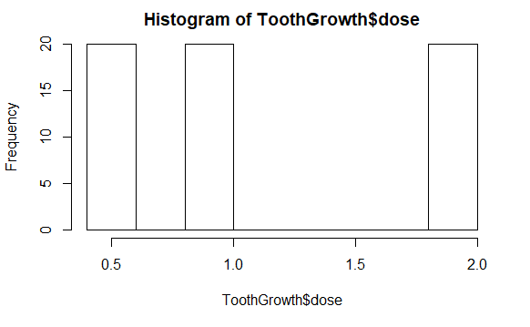

```r
hist(ToothGrowth$dose) # Vitamin C dose
```

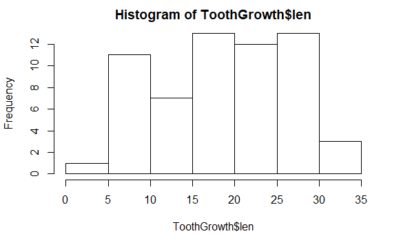

```r
hist(ToothGrowth$len) # Tooth length
```

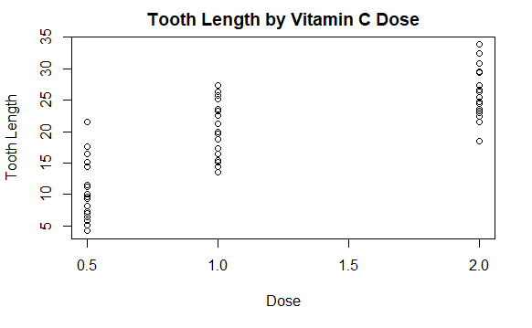

```r
plot(ToothGrowth$len ~ ToothGrowth$dose,
     main = "Tooth Length by Vitamin C Dose",
     xlab = "Dose",
     ylab = "Tooth Length")
```

It looks like tooth lengths are larger at higher doses of Vitamin C. Interestingly, a dose of 1.5 was not administered, but an equal number of 0.5, 1.0, and 2.0 doses were given. The distribution of tooth lengths is also relatively normal.

## Provide a basic summary of the data

```r
nrow(ToothGrowth)
```

```
[1] 60
```

```r
summary(ToothGrowth)
```

```
      len        supp         dose
 Min.   : 4.20   OJ:30   Min.   :0.500
 1st Qu.:13.07   VC:30   1st Qu.:0.500
 Median :19.25           Median :1.000
 Mean   :18.81           Mean   :1.167
 3rd Qu.:25.27           3rd Qu.:2.000
 Max.   :33.90           Max.   :2.000
```

## Use confidence intervals and/or hypothesis tests to compare tooth growth by supp and dose. (Only use the techniques from class, even if there’s other approaches worth considering)

### Differences by supplement

First let’s compare length by supplement, ignoring dose.

```r
t.test(ToothGrowth$len ~ ToothGrowth$supp,
       alt = "two.sided",
       paired = FALSE)
```

```
    Welch Two Sample t-test

data:  ToothGrowth$len by ToothGrowth$supp
t = 1.9153, df = 55.309, p-value = 0.06063
alternative hypothesis: true difference in means is not equal to 0
95 percent confidence interval:
 -0.1710156  7.5710156
sample estimates:
mean in group OJ mean in group VC
        20.66333         16.96333
```

In social sciences we would call a p-value less than .10 “marginally significant”. So that’s one way to interpret this difference. Maybe OJ is more effective at increasing tooth growth?

### Differences by dose

Next let’s look at differences by dose. Since we are using only techniques from class, we will create pairs and test each pair separately, adjusting for family-wise error by multiplying the p-value by the number of pairs tested.

```r
dose1 <- ToothGrowth[ToothGrowth$dose==0.5,]
dose2 <- ToothGrowth[ToothGrowth$dose==1.0,]
dose3 <- ToothGrowth[ToothGrowth$dose==2.0,]

# Pair 1 (0.5 vs. 1.0)
t.test(dose1$len, dose2$len,
       alt = "two.sided",
       paired = FALSE)$p.value * 3 -> pair1.p

# Pair 2 (0.5 vs. 2.0)
t.test(dose1$len, dose3$len,
       alt = "two.sided",
       paired = FALSE)$p.value * 3 -> pair2.p

# Pair 3 (1.0 vs. 2.0)
t.test(dose2$len, dose3$len,
       alt = "two.sided",
       paired = FALSE)$p.value * 3 -> pair3.p

mean(dose1$len)
```

```
[1] 10.605
```

```r
mean(dose2$len)
```

```
[1] 19.735
```

```r
mean(dose3$len)
```

```
[1] 26.1
```

```r
pair1.p
```

```
[1] 3.804902e-07
```

```r
pair2.p
```

```
[1] 1.319257e-13
```

```r
pair3.p
```

```
[1] 5.719289e-05
```

We see that there are significant differences between the doses: At larger doses we see more tooth growth.